# 01_graphics_assignment

# Graphics assignment

```r
url1 <- "https://www.dropbox.com/s/fey54ngk8g4z6rr/exdata_data_NEI_data.zip?dl=0"
destfile1 <- "destfile.zip"

if(!file.exists(destfile1)) {
    download.file(url1,
                  destfile = destfile1,
                  method = "curl")
    unzip(destfile1, exdir = ".")
}

NEI <- readRDS("summarySCC_PM25.rds")
SCC <- readRDS("Source_Classification_Code.rds")
```

## Questions

1. Have total emissions from PM2.5 decreased in the United States from 1999 to 2008? Make a plot showing the **total** PM2.5 emission from all sources for each of the years 1999, 2002, 2005, and 2008.
2. Have total emissions from PM2.5 decreased in the **Baltimore City**, Maryland (`fips == "24510"`) from 1999 to 2008?
3. Of the four types of sources indicated by the `type` (point, nonpoint, onroad, nonroad) variable, which of these four sources have seen decreases in emissions from 1999–2008 for **Baltimore City**? Which have seen increases in emissions from 1999–2008?
4. Across the United States, how have emissions from coal combustion-related sources changed from 1999–2008?
5. How have emissions from motor vehicle sources changed from 1999–2008 in **Baltimore City** (EI.Sector starts from “Mobile”)?
6. Compare emissions from motor vehicle sources in Baltimore City with emissions from motor vehicle sources in **Los Angeles County**, California (`fips == "06037"`). Which city has seen greater changes over time in motor vehicle emissions?

```r
head(NEI)
```

```
##     fips      SCC Pollutant Emissions  type year
## 4  09001 10100401  PM25-PRI    15.714 POINT 1999
## 8  09001 10100404  PM25-PRI   234.178 POINT 1999
## 12 09001 10100501  PM25-PRI     0.128 POINT 1999
## 16 09001 10200401  PM25-PRI     2.036 POINT 1999
## 20 09001 10200504  PM25-PRI     0.388 POINT 1999
## 24 09001 10200602  PM25-PRI     1.490 POINT 1999
```

```r
library(dplyr)
tot.emissions.year <- NEI %>%# Group by year and summarize total emissions across the board
    group_by(year) %>%
    summarize(Total.Emissions = sum(Emissions, na.rm = TRUE))

tot.emissions.year
```

```
## # A tibble: 4 x 2
##    year Total.Emissions
##   <int>           <dbl>
## 1  1999        7332967.
## 2  2002        5635780.
## 3  2005        5454703.
## 4  2008        3464206.
```

1. Have total emissions from PM2.5 decreased in the United States from 1999 to 2008? Make a plot showing the **total** PM2.5 emission from all sources for each of the years 1999, 2002, 2005, and 2008.

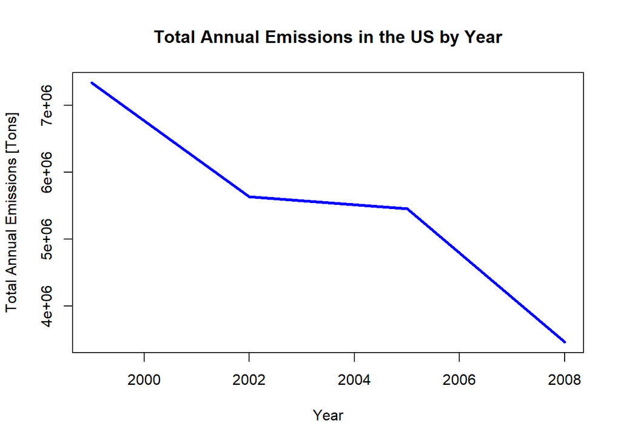

```r
with(tot.emissions.year, # plot data
     plot(x = year,
          y = Total.Emissions,
          type="l",
          ylab = "Total Annual Emissions [Tons]",
          xlab = "Year",
          main = "Total Annual Emissions in the US by Year",
          cex = 2,
          lty = 1,
          col = "blue",
          lwd = 3))
```

2. Have total emissions from PM2.5 decreased in the **Baltimore City**, Maryland (`fips == "24510"`) from 1999 to 2008?

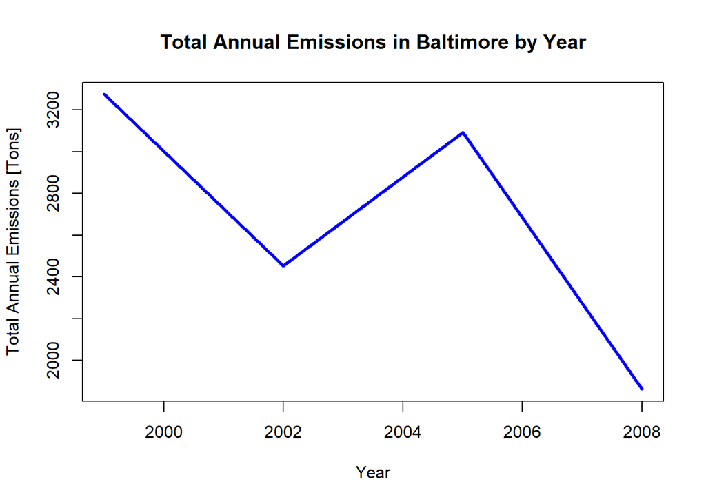

```r
tot.emissions.baltimore <- NEI %>%
        subset(fips == "24510") %>%
        group_by(year) %>%
        summarize(Total.Emissions.Baltimore = sum(Emissions,
                                                  na.rm = TRUE))

with(tot.emissions.baltimore,
     plot(x = year,
          y = Total.Emissions.Baltimore,
           type="l",
          ylab = "Total Annual Emissions [Tons]",
          xlab = "Year",
          main = "Total Annual Emissions in Baltimore by Year",
          cex = 2,

          col = "blue",
          lwd = 3))
```

3. Of the four types of sources indicated by the `type` (point, nonpoint, onroad, nonroad) variable, which of these four sources have seen decreases in emissions from 1999–2008 for **Baltimore City**? Which have seen increases in emissions from 1999–2008?

```r
library(tidyverse)
tot.emissions.type <- NEI %>%
    subset(fips == "24510") %>%
    group_by(year, type) %>%
    summarize(Total.Emissions.Type = sum(Emissions, na.rm = TRUE))
```

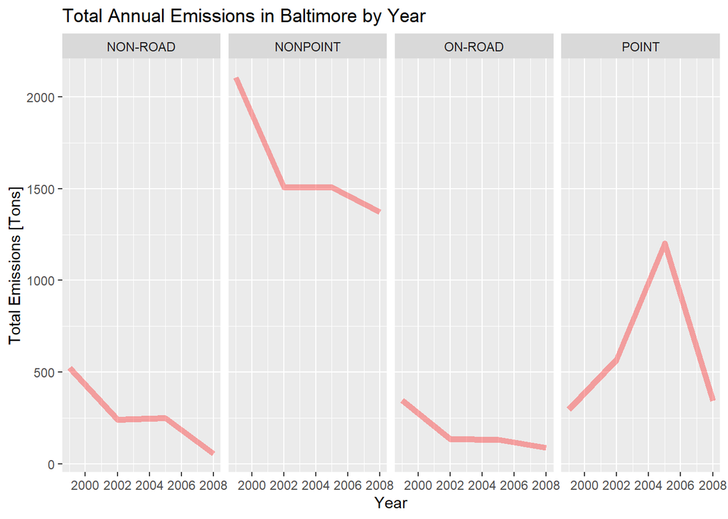

```r
emissions.type <- ggplot(data = tot.emissions.type, aes(year, Total.Emissions.Type))

emissions.type <- emissions.type +
    geom_line(color = "red",
               size = 2,
               alpha = 1/3) +
    facet_grid(. ~ type) +
    xlab("Year") +
    ylab("Total Emissions [Tons]") +
    ggtitle("Total Annual Emissions in Baltimore by Year")

emissions.type
```

4. Across the United States, how have emissions from coal combustion-related sources changed from 1999–2008?

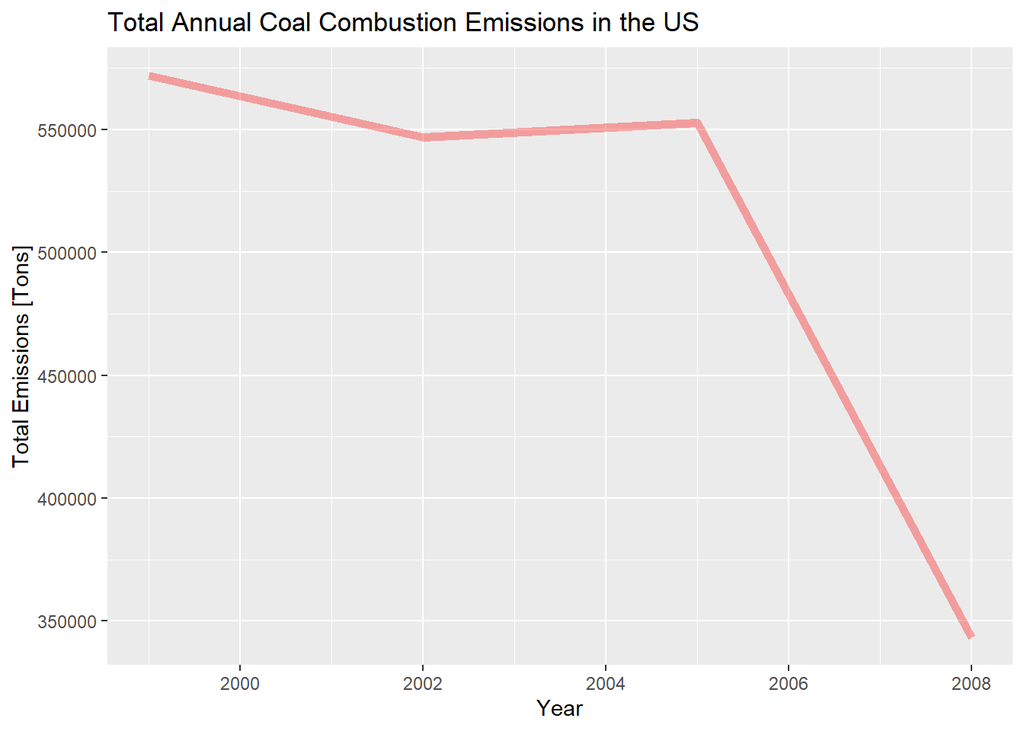

```r
SCC.coal.comb <- SCC[grep("[Cc]oal",SCC$EI.Sector),]
NEI.sub.coal <- subset(NEI,
                       NEI$SCC %in% SCC.coal.comb$SCC)


NEI.coal.comb <- merge(x = NEI.sub.coal,
                       y = SCC,
                       by.x = "SCC",
                       by.y = "SCC")

NEI.coal.comb.tot <- NEI.coal.comb %>%
    group_by(year) %>%
    summarize(Total.Coal.Comb = sum(Emissions, na.rm = TRUE))

NEI.coal.comb.plot <- ggplot(NEI.coal.comb.tot, aes(year, Total.Coal.Comb))

NEI.coal.comb.plot <- NEI.coal.comb.plot +
    geom_line(color = "red",
               size = 2 ,
               alpha = 1/3) +
    xlab("Year") +
    ylab("Total Emissions [Tons]") +
    ggtitle("Total Annual Coal Combustion Emissions in the US")

NEI.coal.comb.plot
```

```r
NEI.coal.comb.tot.2008 <- NEI.coal.comb.tot[NEI.coal.comb.tot$year == 2008, 2]
NEI.coal.comb.tot.1999 <- NEI.coal.comb.tot[NEI.coal.comb.tot$year == 1999, 2]

NEI.coal.comb.delta <- NEI.coal.comb.tot.2008 - NEI.coal.comb.tot.1999
NEI.coal.comb.delta
```

```
##   Total.Coal.Comb
## 1       -228694.3
```

5. How have emissions from motor vehicle sources changed from 1999–2008 in **Baltimore City** (EI.Sector starts from “Mobile”)?

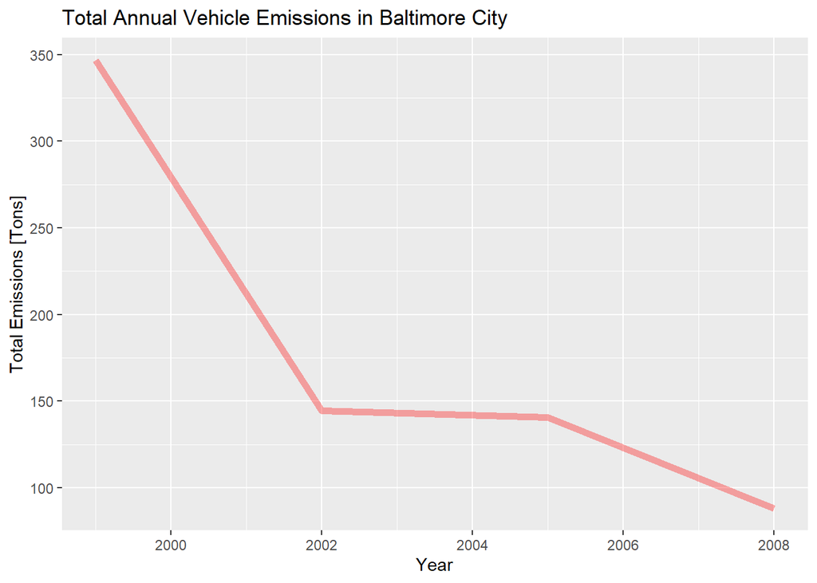

```r
vehicle.scc <- SCC[grep("[Vv]eh", SCC$Short.Name), ]

emissions.motor.baltimore <- NEI %>%
    subset(fips == "24510" & NEI$SCC %in% vehicle.scc$SCC) %>%
    merge(y = vehicle.scc, by.x = "SCC", by.y = "SCC") %>%
    group_by(year) %>%
    summarize(Vehicle.Emissions.Type = sum(Emissions, na.rm = TRUE))


emissions.motor.baltimore.plot <- ggplot(emissions.motor.baltimore, aes(year, Vehicle.Emissions.Type)) +
    geom_line(color = "red",
               size =2,
               alpha = 1/3) +
    xlab("Year") +
    ylab("Total Emissions [Tons]") +
    ggtitle("Total Annual Vehicle Emissions in Baltimore City")

emissions.motor.baltimore.plot
```

6. Compare emissions from motor vehicle sources in Baltimore City with emissions from motor vehicle sources in **Los Angeles County**, California (`fips == "06037"`). Which city has seen greater changes over time in motor vehicle emissions?

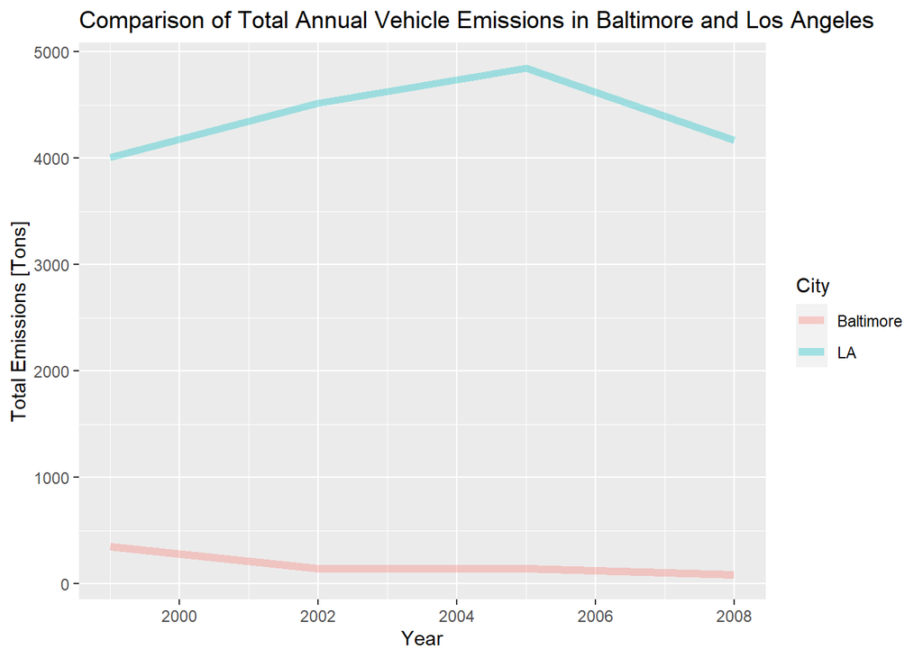

```r
vehicle.scc <- SCC[grep("[Vv]eh", SCC$Short.Name), ]

emissions.motor.la <- NEI %>%
    subset(fips == "06037" & NEI$SCC %in% vehicle.scc$SCC) %>%
    merge(y = vehicle.scc, by.x = "SCC", by.y = "SCC") %>%
    group_by(year) %>%
    summarize(Vehicle.Emissions.Type = sum(Emissions, na.rm = TRUE))

emissions.motor.baltimore2 <- cbind(emissions.motor.baltimore, "City" = rep("Baltimore", 4))
emissions.motor.la2 <- cbind(emissions.motor.la, "City" = rep("LA", 4))

emissions.motor.comp <- rbind(emissions.motor.baltimore2, emissions.motor.la2)

emissions.motor.comp.plot <- ggplot(emissions.motor.comp, aes(year, Vehicle.Emissions.Type, col = City)) +
    geom_line(size =2,
               alpha = 1/3) +
    xlab("Year") +
    ylab("Total Emissions [Tons]") +
    ggtitle("Comparison of Total Annual Vehicle Emissions in Baltimore and Los Angeles")

emissions.motor.comp.plot
```